# Single Cell Analysis

Shrutii Sarda

March 24, 2017

Loading data..

# 1) Metrics of variability

## Number of genes detected per sample:

```r
genes.per.cell = table(mat@j)
```

Displaying the counts in the first few cells..

```r
head(genes.per.cell)
```

```
##
##    0    1    2    3    4    5
##  781 1352 1131  960  522  782
```

Plotting the distribution and summary..

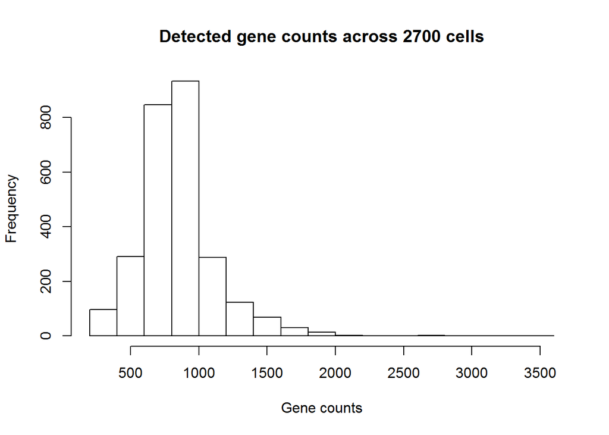

```r
hist(as.numeric(genes.per.cell), main="Detected gene counts across 2700 cells",xlab="Gene counts")
```

```r
summary(as.numeric(genes.per.cell))
```

```
##    Min. 1st Qu.  Median    Mean 3rd Qu.    Max.
##   212.0   690.0   817.0   847.0   953.2  3422.0
```

It does appear that there is considerable variability in the number of genes detected per sample, and the data appears right-skewed.

## Finding highly variable genes:

Before we identify genes, we need to process the count matrix to remove outlier genes, cells, and carryout normalization to adjust for unknown or noisy sources of variability.  
To do so, we carryout the following steps:

1. Remove genes expressed too few cells
2. Remove cells expressing too few genes (too simple)
3. Remove cells expressing too many genes (too complex)
4. Center and scale gene-wise to offset effect of outlier gene expression values and make them comparable
5. Normalize cell-wise by an apppropriate scaling factor to make cells comparable
6. Log transform counts
7. Remove the effects of ‘unwanted’ sources of variation, here a linear model that keeps the residuals after regressing out the effects of the varying counts of unique molecular identifiers detected per cell.

We use functions across several R and Bioconductor packages to accomplish the above:

```r
library(dplyr)
library(Seurat)
seurat_mat <- new("seurat", raw.data = mat)
sc <- Setup(seurat_mat, min.cells = 5, min.genes = 300, do.logNormalize = T, total.expr = 1e4, project = "singlecell")
sc <- SubsetData(sc, subset.name = "nGene", accept.high = 2500)
sc <- RegressOut(sc, latent.vars = c("nUMI"))
```

```
## [1] "Regressing out nUMI"
```

The above genes can be visualized on a mean expression vs. log(variance/mean) plot of all genes, as shown below.

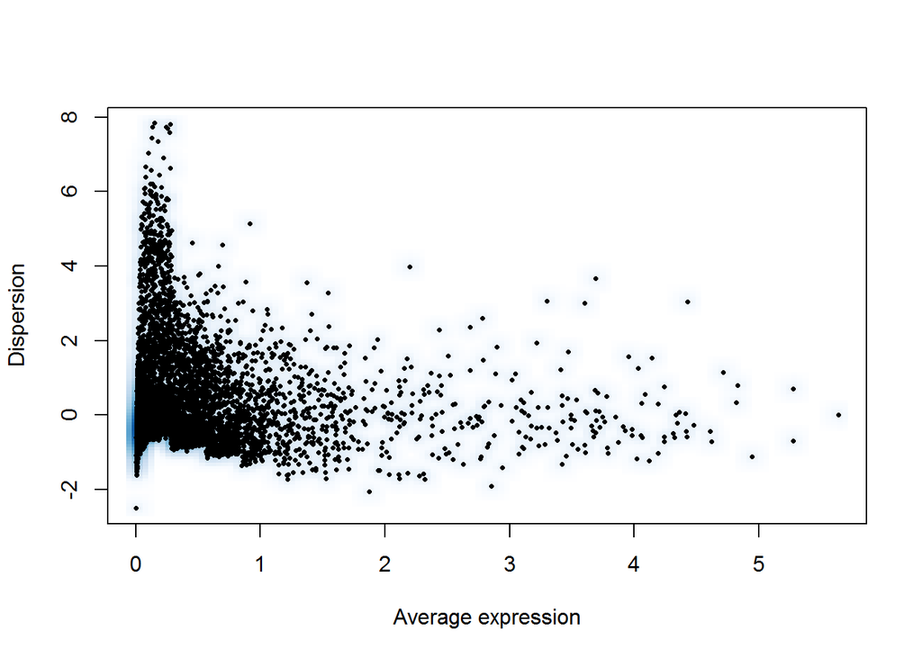

```r
sc <- MeanVarPlot(sc, fxn.x = expMean, fxn.y = logVarDivMean, x.low.cutoff = 0.0125, x.high.cutoff = 3, y.cutoff = 0.5, do.contour = F, do.text = F)
```

```r
length(sc@var.genes)
```

```
## [1] 1769
```

The number of highly variable genes detected by this method is 1769.

There is a strong relationship between mean expression and variance, with several genes exhibiting much higher variance as their absolute expression increases. In fact, even a Poisson model is insufficient to model this relationship, requiring the need for negative binomial models for gene expression data to account for over-dispersion (variance > mean). Therefore it becomes necessary to control for absolute gene expression values when detecting highly variable genes, justifying the methods we used above.

## Do the identified genes make sense?

1. We can look at the gene expression profiles of some of the highly variable genes identified above to check if they are really very different across the board. Below we plot this distribution for a few different genes..

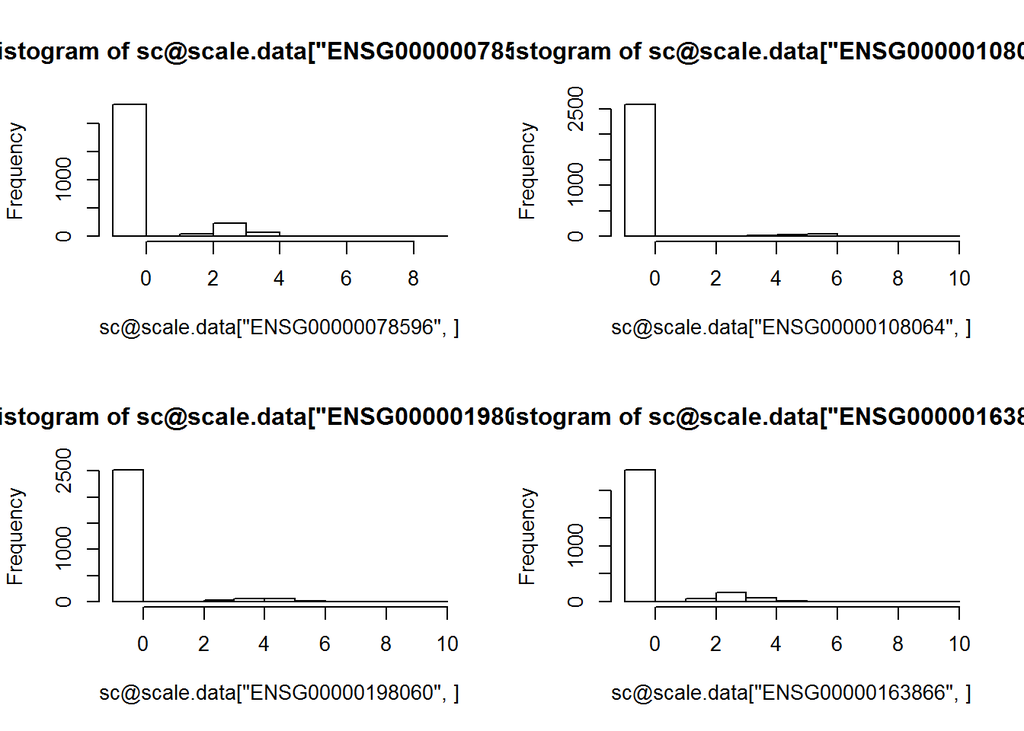

```r
par(mfrow=c(2,2))
hist(sc@scale.data["ENSG00000078596",])
hist(sc@scale.data["ENSG00000108064",])
hist(sc@scale.data["ENSG00000198060",])
hist(sc@scale.data["ENSG00000163866",])
```

Clearly, all these genes have distinct “clusters” in their expression profiles, indicated by the bimodality of these curves.

2. We can also perform Gene Ontology enrichment analysis to check if there overrepresented terms that are characteristic of the specific functions carried out by the distinct population of cells surveyed in this analysis.

```r
library(biomaRt)
library(org.Hs.eg.db)
library(topGO)

GO_genes <- rep(1,length(genes))
names(GO_genes) = genes
GO_genes[names(GO_genes) %in% sc@var.genes] = 0

GOdata <- new("topGOdata", ontology = "BP", allGenes = GO_genes, geneSel = function(p) p < 1e-2, description = "Test", annot = annFUN.org, mapping="org.Hs.eg.db", ID="Ensembl")

resultFisher <- runTest(GOdata, algorithm = "classic", statistic = "fisher")

GenTable(GOdata, classicFisher = resultFisher, topNodes = 10)
```

```
##         GO.ID                                        Term Annotated
## 1  GO:0006955                             immune response      1429
## 2  GO:0002376                       immune system process      2253
## 3  GO:0002684 positive regulation of immune system pro...       857
## 4  GO:0002682         regulation of immune system process      1241
## 5  GO:0050776               regulation of immune response       811
## 6  GO:0002768 immune response-regulating cell surface ...       325
## 7  GO:0050778      positive regulation of immune response       599
## 8  GO:0002429 immune response-activating cell surface ...       293
## 9  GO:0048584 positive regulation of response to stimu...      1868
## 10 GO:0007005                  mitochondrion organization       621
##    Significant Expected classicFisher
## 1          225   132.10       1.2e-16
## 2          310   208.28       2.2e-14
## 3          143    79.23       1.0e-12
## 4          187   114.72       4.1e-12
## 5          131    74.97       9.8e-11
## 6           67    30.04       2.4e-10
## 7          103    55.37       3.4e-10
## 8           62    27.09       3.8e-10
## 9          248   172.69       6.7e-10
## 10         102    57.41       5.3e-09
```

Clearly, there are several cell-type specific processes enriched in this list, indicating that the subpopulations of these cells are involved in regulating immune response (like subpopulations of immune cells, T cells, B cells etc..)

# 2) Gene expression vs. gene length

First, we get the length of the longest transcript for each gene (=sum of nucleotides covered by each exon).

```r
library("EnsDb.Hsapiens.v75")
edb <- EnsDb.Hsapiens.v75

get_longest_tx_length = function(x) {max(lengthOf(edb, of = "tx", filter = list(GeneidFilter(x))))}

gene_lengths = sapply(rownames(sc@scale.data), get_longest_tx_length)
```

To explore the relationship between gene expression and gene length, we will plot gene length on the Y-axis, and gene expression on the X-axis (for a few cell types). We can also compute the significance of the Spearman correlation of gene lengths with expression profile to get a quantitative estimate of the relationship.

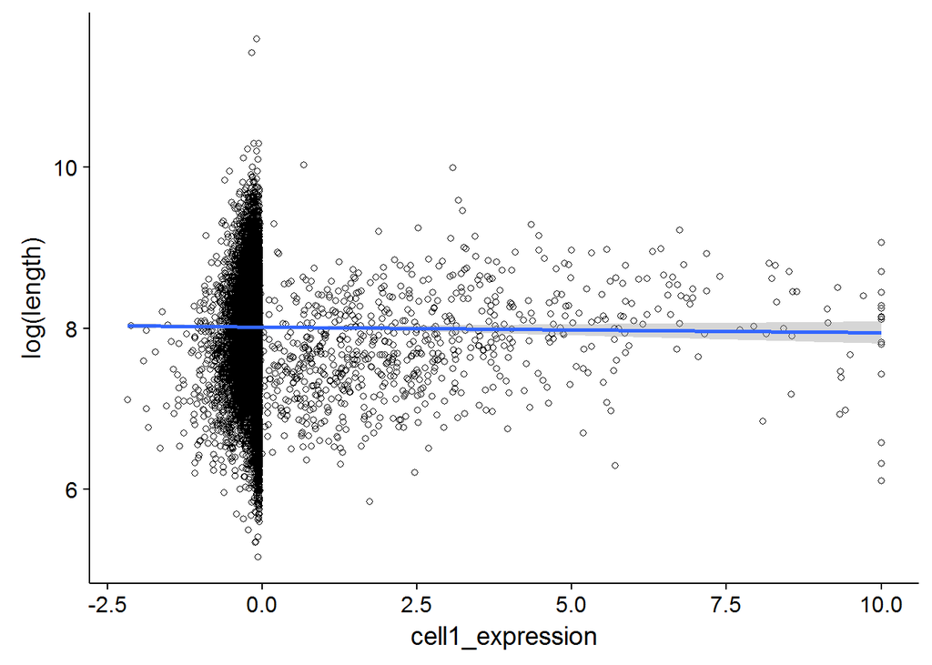

```r
df = data.frame(cell1_expression=sc@scale.data[,1], cell2_expression=sc@scale.data[,100], length=gene_lengths)

par(mfrow=c(1,2))
ggplot(df, aes(x=cell1_expression, y=log(length))) + geom_point(shape=1) + geom_smooth(method=lm)
```

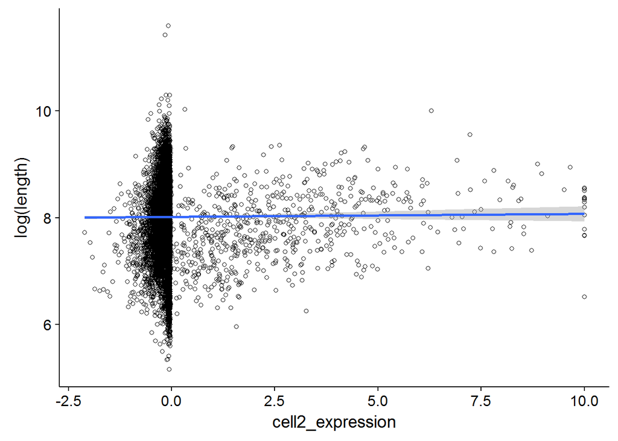

```r
ggplot(df, aes(x=cell2_expression, y=log(length))) + geom_point(shape=1) + geom_smooth(method=lm)
```

```r
cor.test(df$cell1_expression, log(df$length), method="spearman")$p.value
```

```
## [1] 0.3700831
```

```r
cor.test(df$cell2_expression, log(df$length), method="spearman")$p.value
```

```
## [1] 0.4024049
```

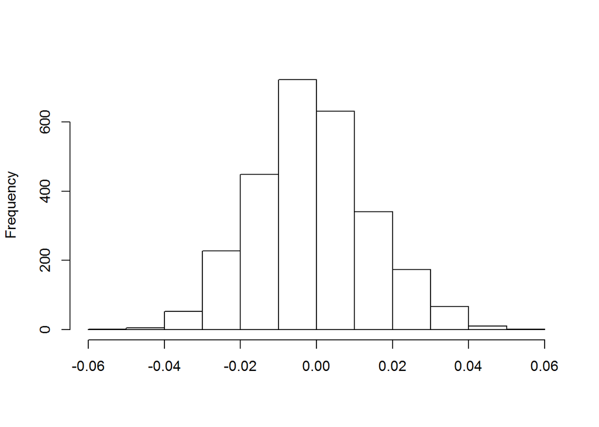

```r
get_rho = function(x) {as.numeric(cor.test(x,log(df$length),method="spearman")$estimate)}
cors = apply(sc@scale.data, 2, get_rho)
hist(cors, main="", xlab="")
```

Clearly, there is no correlation between the computed measures of gene expression and length.

Note: It is important to clarify that there exists no relationship between these single-cell computed measures of gene expression and length, because only the end(s) of the transcript which contains the UMI are preferentially sequenced and NOT the entire length. Further, technical biases in single-cell sequencing and quantification of RNA are reduced due to ERCC spike-in controls (with varying RNA length & GC content) and unique molecular identifiers (UMIs). It was inferred that by introducing the spike-in controls and counting the molecules rather than the number of amplified sequencing reads, one can account for biases related to amplification, and obtain more accurate estimates of gene expression levels. Otherwise, in regular (bulk) RNA-seq experiments, gene expression and length are highly positively correlated. This is precisely why RPKM/FPKM (Reads/Fragments Per Kilobase of transcript per Million mapped reads) measures of gene expression that adjust for gene length and sequencing depth were developed.

# 3) Determining the identity of cell-type subpopulations amongst all cells as well as their gene signatures.

## Clustering to identify subpopulations

To recap our search space, after filtering and scaling data, we now have 12565 genes and 2680 samples, with 1769 highly variable genes. Our objective is to identify subpopulations of cell types amongst the 2680 cells, and this can be done by clustering them based on the overall similarity of gene expression profiles.

To do so, we will carry out the following steps:

1. Even if only the highly variable genes are used to cluster the cells, its still a large number. We will therefore use dimensionality reduction to extract just the “eigen” genes and cluster cells based on these PCs only. We will also assign a score to each true gene based on its correlation with computed PCs.
2. Seurat makes available a powerful clustering technique detects quasi-cliques on a KNN graph where the edges between cells is directly related to the similarity of gene expression patterns. This assigns a cluster “identity” to each cell.
3. We will then use tSNE (t-distributed stochastic neighbor embedding) that reduces the dimensionality further to 2D for visualization, and it is expected that the cluster identified above will co-localize on the tSNE plot.

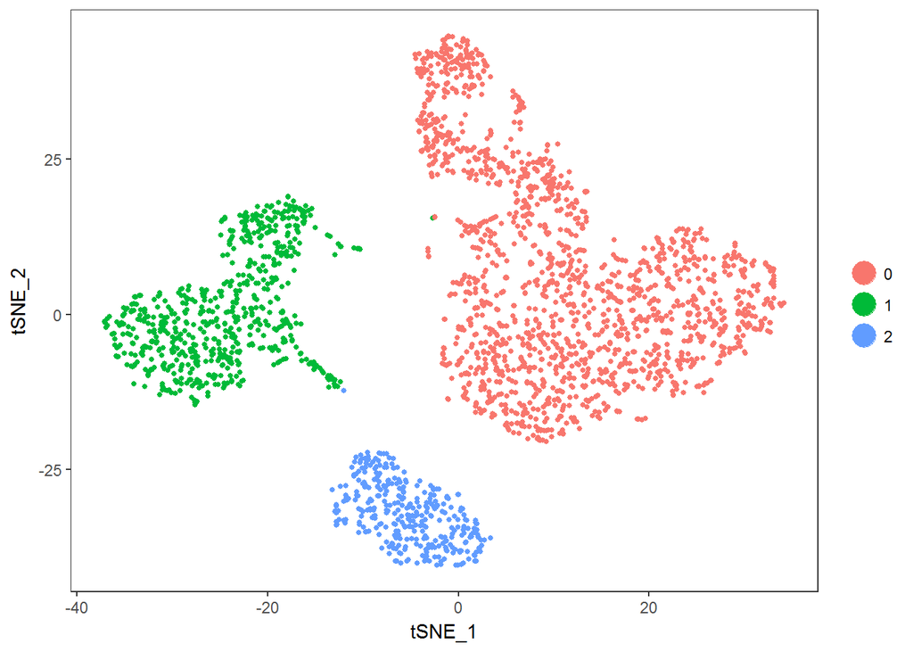

```r
sc <- PCA(sc, pc.genes = sc@var.genes, do.print = F)
sc <- ProjectPCA(sc, do.print = F)

sc <- FindClusters(sc, pc.use = 1:8, resolution = 0.02, print.output = 0, save.SNN = T)
sc <- RunTSNE(sc, dims.use = 1:8, do.fast = T)

TSNEPlot(sc)
```

As we can see, there are 3 distinct cell type subpopulations in this dataset.

## Informing the identity of the subpopulation

1. How many cells per subpopulation?

```r
table(as.vector(sc@ident))
```

```
##
##    0    1    2
## 1638  690  352
```

2. Key genes that identify subpopulations?

For this task, we will carryout differential gene expression of every cluster (foreground) against all other clusters (background), and report both up and down regulated genes. The criteria include:

1. The fold change of a certain gene between foreground and background is > 1.3.
2. A certain gene is expressed (both in foreground and background) in atleast 10% of the cells.
3. The log-likelihood ratio test is used for differential expression of a gene between foreground and background, that essentially tests if the distinct group expression means are significantly different under a statistic that follows a chi-sq distribution.

```r
df = data.frame(names(sc@ident), sc@ident)

clus1.markers <- DiffExpTest(sc, as.vector(df$names.sc.ident.[df$sc.ident == 0]), as.vector(df$names.sc.ident.[df$sc.ident != 0]))
clus2.markers <- DiffExpTest(sc, as.vector(df$names.sc.ident.[df$sc.ident == 1]), as.vector(df$names.sc.ident.[df$sc.ident != 1]))
clus3.markers <- DiffExpTest(sc, as.vector(df$names.sc.ident.[df$sc.ident == 2]), as.vector(df$names.sc.ident.[df$sc.ident != 2]))
```

The top 5 genes that form the signature for each cell type is shown below:

```r
head(clus1.markers[order(clus1.markers$p_val),,drop=F],5)
```

```
##                 p_val
## ENSG00000163131     0
## ENSG00000163220     0
## ENSG00000019582     0
## ENSG00000204287     0
## ENSG00000196126     0
```

```r
head(clus2.markers[order(clus2.markers$p_val),,drop=F],5)
```

```
##                 p_val
## ENSG00000163131     0
## ENSG00000163191     0
## ENSG00000163220     0
## ENSG00000143546     0
## ENSG00000197956     0
```

```r
head(clus3.markers[order(clus3.markers$p_val),,drop=F],5)
```

```
##                         p_val
## ENSG00000019582  0.000000e+00
## ENSG00000255031  0.000000e+00
## ENSG00000105369  0.000000e+00
## ENSG00000007312 2.415515e-305
## ENSG00000204287 8.121892e-302
```

Displaying some of the signature genes.

[figure not shown]

```r
VlnPlot(sc, c("ENSG00000163191","ENSG00000007312","ENSG00000163220","ENSG00000105369"))
```

3. Based on their biological signatures, it appears that the subpopulations correspond to 3 major types, T cells, B cells and Monocytes.

## Detecting more structure

By adjusting the parameters of the clustering algorithm, specifically increasing the resolution of the SNN method, we can attempt to detect finer structure.

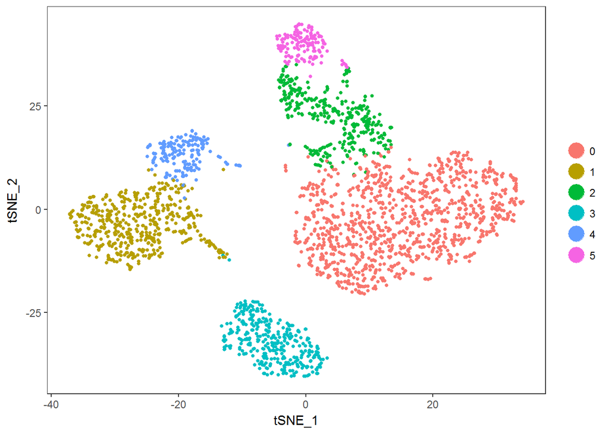

```r
sc <- FindClusters(sc, pc.use = 1:8, resolution = 0.5, print.output = 0, save.SNN = T)
sc <- RunTSNE(sc, dims.use = 1:8, do.fast = T)

TSNEPlot(sc)
```

Using this resolution, we identify a total of 6 clusters.

# 4) Detecting clusters with fewer samples

## Generalizing the pipeline for clustering..

```r
sc_cluster = function(fewer_cells, resol=0.02, perplex = 30)
{

  seurat_mat <- new("seurat", raw.data = mat)
  sc <- Setup(seurat_mat, min.cells = 5, min.genes = 300, do.logNormalize = T, total.expr = 1e4, project = "singlecell")
  sc <- SubsetData(sc, subset.name = "nGene", accept.high = 2500)
  sc <- SubsetData(sc, cells.use = sample(dim(sc@data)[2], fewer_cells, replace=F))
  sc <- RegressOut(sc, latent.vars = c("nUMI"))
  sc <- MeanVarPlot(sc, fxn.x = expMean, fxn.y = logVarDivMean, x.low.cutoff = 0.0125, x.high.cutoff = 3, y.cutoff = 0.5, do.plot = F, do.contour = F, do.text = F)
  sc <- PCA(sc, pc.genes = sc@var.genes, do.print = F)
  sc <- ProjectPCA(sc, do.print=F)
  sc <- FindClusters(sc, pc.use = 1:8, resolution = resol, print.output = 0, save.SNN = T)
  sc <- RunTSNE(sc, dims.use = 1:8, do.fast = T, perplexity = perplex)
  TSNEPlot(sc)
}
```

## Running with 10 samples

```r
sc_cluster(10,perplex=3)
```

```
## [1] "Regressing out nUMI"
```

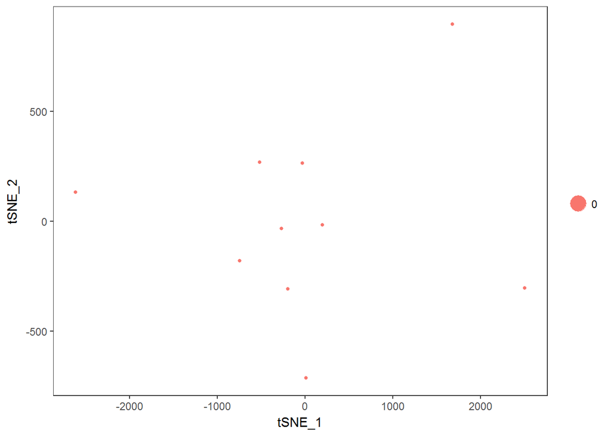

The 3 clusters cannot be resolved using only 10 samples whilst using the same resolution for clustering.

P.S. The samples are too few to carry out standard t-SNE. I have drastically reduced the perplexity (expected number of nearest neighbors) in the algorithm to allow it to complete.

```r
sc_cluster(10,resol=0.8,perplex=3)
```

```
## [1] "Regressing out nUMI"
```

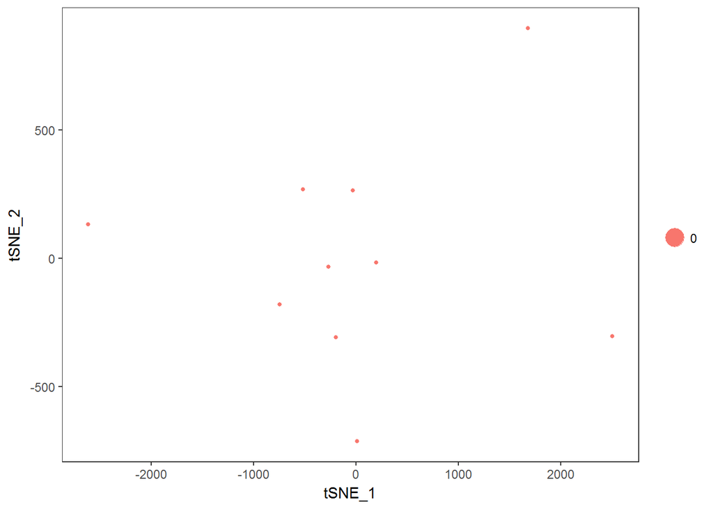

Even with an increased clustering resolution, the clustering fails to discern the 3 subpopulations.

## Running with 100 samples

```r
sc_cluster(100)
```

```
## [1] "Regressing out nUMI"
```

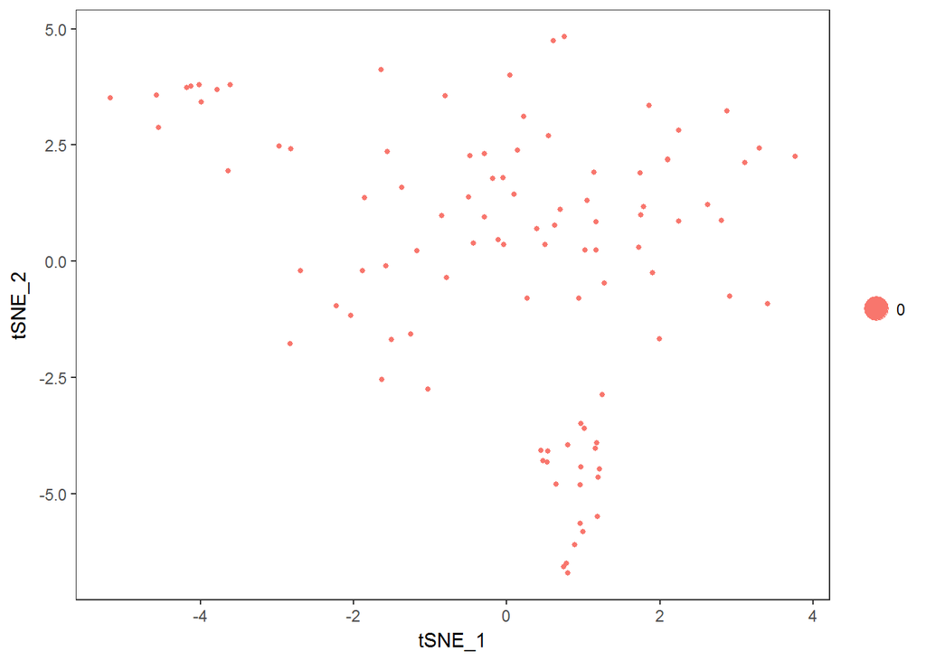

The 3 clusters cannot be resolved using only 100 samples whilst using the same resolution for clustering.

```r
sc_cluster(100,resol=0.8)
```

```
## [1] "Regressing out nUMI"
```

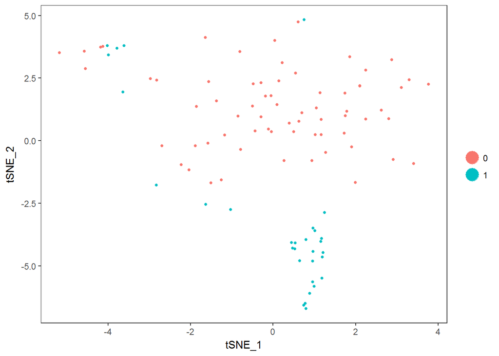

By increasing the resolution of the clustering method, 2 clusters are detected. Although it is hard to say which subpopulations they correspond to.

## Running with 1000 samples

```r
sc_cluster(1000)
```

```
## [1] "Regressing out nUMI"
```

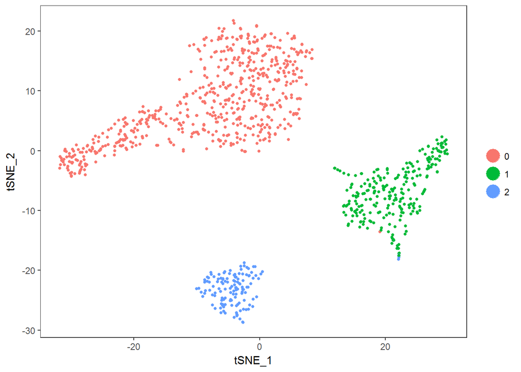

The 3 clusters, or subpopulations are still detectable using only 1000 samples whilst using the same resolution for clustering.

# 5) Downsampling gene counts

To downsample the gene counts by 1/5th (or 0.2th), each entry X(ij) in the matrix will be sampled down to Y(ij) from a binomial distribution such that, Y(ij) ~ Binom(X(ij),0.2)

Note: We only need to do this for all the non-zero entries of the sparse matrix, as the mean and variance of the X(ij)=0 distributions are zero themselves.

```r
down_mat = mat
down_mat@x = as.numeric(sapply(down_mat@x, function(x) {rbinom(1,x,0.2)}))
seurat_down_mat <- new("seurat", raw.data = down_mat)
down_sc <- Setup(seurat_down_mat, min.cells = 5, min.genes = 300, do.logNormalize = T, total.expr = 1e4, project = "singlecell")
down_sc <- SubsetData(down_sc, subset.name = "nGene", accept.high = 2500)
down_sc <- RegressOut(down_sc, latent.vars = c("nUMI"))
```

```
## [1] "Regressing out nUMI"
```

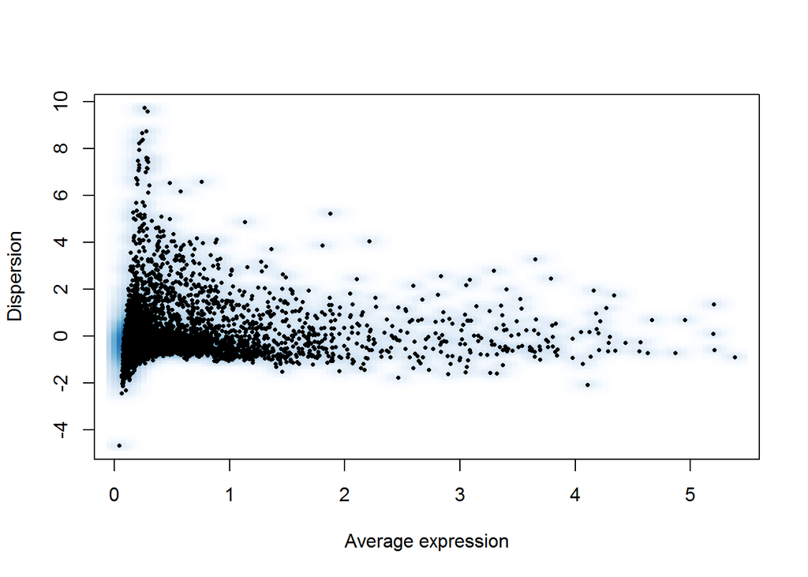

```r
down_sc <- MeanVarPlot(down_sc, fxn.x = expMean, fxn.y = logVarDivMean, x.low.cutoff = 0.0125, x.high.cutoff = 3, y.cutoff = 0.5, do.contour = F, do.text = F)
```

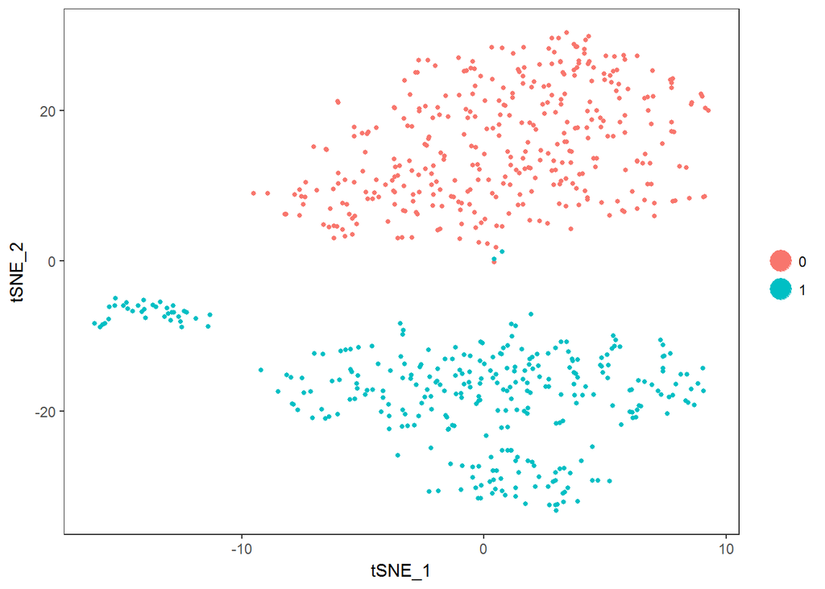

```r
down_sc <- PCA(down_sc, pc.genes = down_sc@var.genes, do.print = F)
down_sc <- ProjectPCA(down_sc, do.print=F)
down_sc <- FindClusters(down_sc, pc.use = 1:8, resolution = 0.02, print.output = 0, save.SNN = T)
down_sc <- RunTSNE(down_sc, dims.use = 1:8, do.fast = T)
TSNEPlot(down_sc)
```

The 3 clusters cannot be resolved after downsampling to 1/5th whilst using the same resolution for clustering. Of course, the number of clusters can be adjusted by tuning the resolution parameter in the SNN algorithm. Whether the membership of cells to different subpopulations will be preserved too is hard to say.